# West Midlands EFDI — Spatial Weights and Moran’s I

Bernard Ofosu

19 November 2026

# 1 1. Project overview

This analysis examines spatial autocorrelation in the E-food Desert Index (EFDI) across 2,365 Lower Layer Super Output Areas (LSOAs) in the West Midlands, England.

Four spatial weighting methods are constructed and compared:

1. Queen contiguity
2. K-nearest neighbours (KNN6)
3. Distance band (6 km)
4. Inverse distance (6 km, power 1)

The analysis examines neighbour structures, spatial weights, Global Moran’s I, Local Moran’s I, spatial patterns and descriptive statistics.

**Input:** `efdi_wm_clean.gpkg`

**Identifier:** `lsoa01cd`

**Geometry column:** `geom`

**Analysis CRS:** EPSG:27700 — OSGB36 / British National Grid.

# 2 2. Install and load packages

```r
packages <- c(
  "sf",
  "spdep",
  "spatialreg",
  "dplyr",
  "ggplot2",
  "tidyr",
  "purrr",
  "knitr"
)

missing_packages <- packages[
  !packages %in% rownames(installed.packages())
]

if (length(missing_packages) > 0) {
  install.packages(missing_packages)
}

library(sf)
library(spdep)
library(spatialreg)
library(dplyr)
library(ggplot2)
library(tidyr)
library(purrr)
library(knitr)

set.seed(12345)

# Show package versions
packageVersion("sf")
```

```
## [1] '1.1.3'
```

```r
packageVersion("spdep")
```

```
## [1] '1.4.2'
```

```r
packageVersion("spatialreg")
```

```
## [1] '1.4.3'
```

# 3 3. Read the West Midlands dataset

```r
# Project directory
project_dir <- "D:/Spatial Data Analysis"

# Input GeoPackage
data_path <- file.path(
  project_dir,
  "efdi_wm_clean.gpkg"
)

# Confirm file exists
if (!file.exists(data_path)) {
  stop("The GeoPackage file could not be found.")
}

# Read spatial data
food <- st_read(
  data_path,
  quiet = TRUE
)

# Inspect data
head(food)
```

```
## Simple feature collection with 6 features and 8 fields
## Geometry type: MULTIPOLYGON
## Dimension:     XY
## Bounding box:  xmin: 402335.2 ymin: 285897.5 xmax: 406333.9 ymax: 287742.9
## Projected CRS: OSGB36 / British National Grid
##    lsoa01cd        lsoa01nm     efdi efdi_decil imd_rank house_pric veg_cov
## 1 E01009143 Birmingham 059B 38.30457          1      765   220000.0   0.810
## 2 E01009145 Birmingham 060D 18.79994          6    10049   230747.5   0.924
## 3 E01009146 Birmingham 059D 26.37110          3     3785   271875.0   0.512
## 4 E01009147 Birmingham 060E 18.25160          6     2695   339150.0   0.849
## 5 E01009151 Birmingham 053A 26.51394          3     4545   145500.0   0.446
## 6 E01009152 Birmingham 053B 29.58538          2     2203   251000.0   0.642
##   res_mob                           geom
## 1   0.084 MULTIPOLYGON (((405343 2867...
## 2   0.143 MULTIPOLYGON (((403486.6 28...
## 3   0.201 MULTIPOLYGON (((406107.1 28...
## 4   0.172 MULTIPOLYGON (((403193.5 28...
## 5   0.082 MULTIPOLYGON (((403690.4 28...
## 6   0.054 MULTIPOLYGON (((404124.2 28...
```

```r
# Number of observations
nrow(food)
```

```
## [1] 2365
```

```r
# Column names
names(food)
```

```
## [1] "lsoa01cd"   "lsoa01nm"   "efdi"       "efdi_decil" "imd_rank"
## [6] "house_pric" "veg_cov"    "res_mob"    "geom"
```

```r
# Geometry column name
attr(food, "sf_column")
```

```
## [1] "geom"
```

```r
# Data structure
str(food)
```

```
## Classes 'sf' and 'data.frame':   2365 obs. of  9 variables:
##  $ lsoa01cd  : chr  "E01009143" "E01009145" "E01009146" "E01009147" ...
##  $ lsoa01nm  : chr  "Birmingham 059B" "Birmingham 060D" "Birmingham 059D" "Birmingham 060E" ...
##  $ efdi      : num  38.3 18.8 26.4 18.3 26.5 ...
##  $ efdi_decil: num  1 6 3 6 3 2 3 2 3 4 ...
##  $ imd_rank  : num  765 10049 3785 2695 4545 ...
##  $ house_pric: num  220000 230748 271875 339150 145500 ...
##  $ veg_cov   : num  0.81 0.924 0.512 0.849 0.446 0.642 0.682 0.996 0.995 0.69 ...
##  $ res_mob   : num  0.084 0.143 0.201 0.172 0.082 0.054 0.107 0.028 0.044 0.086 ...
##  $ geom      :sfc_MULTIPOLYGON of length 2365; first list element: List of 1
##   ..$ :List of 1
##   .. ..$ : num [1:124, 1:2] 405343 405354 405365 405389 405410 ...
##   ..- attr(*, "class")= chr [1:3] "XY" "MULTIPOLYGON" "sfg"
##  - attr(*, "sf_column")= chr "geom"
##  - attr(*, "agr")= Factor w/ 3 levels "constant","aggregate",..: NA NA NA NA NA NA NA NA
##   ..- attr(*, "names")= chr [1:8] "lsoa01cd" "lsoa01nm" "efdi" "efdi_decil" ...
```

```r
# Geometry type
unique(st_geometry_type(food))
```

```
## [1] MULTIPOLYGON
## 18 Levels: GEOMETRY POINT LINESTRING POLYGON MULTIPOINT ... TRIANGLE
```

```r
# CRS
st_crs(food)
```

```
## Coordinate Reference System:
##   User input: OSGB36 / British National Grid
##   wkt:
## PROJCRS["OSGB36 / British National Grid",
##     BASEGEOGCRS["OSGB36",
##         DATUM["Ordnance Survey of Great Britain 1936",
##             ELLIPSOID["Airy 1830",6377563.396,299.3249646,
##                 LENGTHUNIT["metre",1]]],
##         PRIMEM["Greenwich",0,
##             ANGLEUNIT["degree",0.0174532925199433]],
##         ID["EPSG",4277]],
##     CONVERSION["British National Grid",
##         METHOD["Transverse Mercator",
##             ID["EPSG",9807]],
##         PARAMETER["Latitude of natural origin",49,
##             ANGLEUNIT["degree",0.0174532925199433],
##             ID["EPSG",8801]],
##         PARAMETER["Longitude of natural origin",-2,
##             ANGLEUNIT["degree",0.0174532925199433],
##             ID["EPSG",8802]],
##         PARAMETER["Scale factor at natural origin",0.9996012717,
##             SCALEUNIT["unity",1],
##             ID["EPSG",8805]],
##         PARAMETER["False easting",400000,
##             LENGTHUNIT["metre",1],
##             ID["EPSG",8806]],
##         PARAMETER["False northing",-100000,
##             LENGTHUNIT["metre",1],
##             ID["EPSG",8807]]],
##     CS[Cartesian,2],
##         AXIS["(E)",east,
##             ORDER[1],
##             LENGTHUNIT["metre",1]],
##         AXIS["(N)",north,
##             ORDER[2],
##             LENGTHUNIT["metre",1]],
##     USAGE[
##         SCOPE["Engineering survey, topographic mapping."],
##         AREA["United Kingdom (UK) - offshore to boundary of UKCS within 49°45'N to 61°N and 9°W to 2°E; onshore Great Britain (England, Wales and Scotland). Isle of Man onshore."],
##         BBOX[49.75,-9.01,61.01,2.01]],
##     ID["EPSG",27700]]
```

# 4 4. Prepare the analytical dataset

The active geometry column in this GeoPackage is `geom`, not `geometry`. The code below uses `st_geometry()` so that the spatial operations work with the active geometry column.

```r
# Check original CRS
st_crs(food)
```

```
## Coordinate Reference System:
##   User input: OSGB36 / British National Grid
##   wkt:
## PROJCRS["OSGB36 / British National Grid",
##     BASEGEOGCRS["OSGB36",
##         DATUM["Ordnance Survey of Great Britain 1936",
##             ELLIPSOID["Airy 1830",6377563.396,299.3249646,
##                 LENGTHUNIT["metre",1]]],
##         PRIMEM["Greenwich",0,
##             ANGLEUNIT["degree",0.0174532925199433]],
##         ID["EPSG",4277]],
##     CONVERSION["British National Grid",
##         METHOD["Transverse Mercator",
##             ID["EPSG",9807]],
##         PARAMETER["Latitude of natural origin",49,
##             ANGLEUNIT["degree",0.0174532925199433],
##             ID["EPSG",8801]],
##         PARAMETER["Longitude of natural origin",-2,
##             ANGLEUNIT["degree",0.0174532925199433],
##             ID["EPSG",8802]],
##         PARAMETER["Scale factor at natural origin",0.9996012717,
##             SCALEUNIT["unity",1],
##             ID["EPSG",8805]],
##         PARAMETER["False easting",400000,
##             LENGTHUNIT["metre",1],
##             ID["EPSG",8806]],
##         PARAMETER["False northing",-100000,
##             LENGTHUNIT["metre",1],
##             ID["EPSG",8807]]],
##     CS[Cartesian,2],
##         AXIS["(E)",east,
##             ORDER[1],
##             LENGTHUNIT["metre",1]],
##         AXIS["(N)",north,
##             ORDER[2],
##             LENGTHUNIT["metre",1]],
##     USAGE[
##         SCOPE["Engineering survey, topographic mapping."],
##         AREA["United Kingdom (UK) - offshore to boundary of UKCS within 49°45'N to 61°N and 9°W to 2°E; onshore Great Britain (England, Wales and Scotland). Isle of Man onshore."],
##         BBOX[49.75,-9.01,61.01,2.01]],
##     ID["EPSG",27700]]
```

```r
# Transform to British National Grid if necessary
if (st_crs(food)$epsg != 27700) {
  food <- st_transform(food, 27700)
}

# Check required columns
required_fields <- c(
  "lsoa01cd",
  "efdi",
  "geom"
)

missing_fields <- setdiff(
  required_fields,
  names(food)
)

if (length(missing_fields) > 0) {
  stop(
    paste(
      "Missing required fields:",
      paste(missing_fields, collapse = ", ")
    )
  )
}

# Retain observations with EFDI values
food_analysis <- food %>%
  filter(!is.na(efdi))

# Remove empty geometries using the active geometry
food_analysis <- food_analysis[
  !st_is_empty(st_geometry(food_analysis)),
]

# Check unique LSOA identifiers
stopifnot(
  !anyDuplicated(food_analysis$lsoa01cd)
)

# Check and repair invalid geometries
invalid <- !st_is_valid(food_analysis)

if (any(invalid)) {
  food_analysis <- st_make_valid(food_analysis)
}

# Verify analytical dataset
cat("Observations:", nrow(food_analysis), "\n")
```

```
## Observations: 2365
```

```r
cat("Missing EFDI:", sum(is.na(food_analysis$efdi)), "\n")
```

```
## Missing EFDI: 0
```

```r
cat("Empty geometries:",
    sum(st_is_empty(st_geometry(food_analysis))), "\n")
```

```
## Empty geometries: 0
```

```r
cat("Invalid geometries:",
    sum(!st_is_valid(food_analysis)), "\n")
```

```
## Invalid geometries: 0
```

```r
cat("CRS:", st_crs(food_analysis)$epsg, "\n")
```

```
## CRS: 27700
```

```r
# Inspect result
head(food_analysis)
```

```
## Simple feature collection with 6 features and 8 fields
## Geometry type: POLYGON
## Dimension:     XY
## Bounding box:  xmin: 402335.2 ymin: 285897.5 xmax: 406333.9 ymax: 287742.9
## Projected CRS: OSGB36 / British National Grid
##    lsoa01cd        lsoa01nm     efdi efdi_decil imd_rank house_pric veg_cov
## 1 E01009143 Birmingham 059B 38.30457          1      765   220000.0   0.810
## 2 E01009145 Birmingham 060D 18.79994          6    10049   230747.5   0.924
## 3 E01009146 Birmingham 059D 26.37110          3     3785   271875.0   0.512
## 4 E01009147 Birmingham 060E 18.25160          6     2695   339150.0   0.849
## 5 E01009151 Birmingham 053A 26.51394          3     4545   145500.0   0.446
## 6 E01009152 Birmingham 053B 29.58538          2     2203   251000.0   0.642
##   res_mob                           geom
## 1   0.084 POLYGON ((405343 286770, 40...
## 2   0.143 POLYGON ((403486.6 287261, ...
## 3   0.201 POLYGON ((406107.1 286605.7...
## 4   0.172 POLYGON ((403193.5 286135, ...
## 5   0.082 POLYGON ((403690.4 287732.2...
## 6   0.054 POLYGON ((404124.2 287609.5...
```

# 5 5. Create representative points

Queen contiguity uses polygon boundaries. KNN and distance-based weights use representative locations.

A representative point is generated inside each LSOA using `st_point_on_surface()`.

```r
# Generate one point inside each LSOA
representative_points <- st_point_on_surface(
  food_analysis
)
# Extract coordinates
coords <- st_coordinates(
  representative_points
)

# Check coordinates
head(coords)
```

```
##             X        Y
## [1,] 405089.9 286526.9
## [2,] 403379.4 286709.0
## [3,] 406058.8 286283.5
## [4,] 402580.8 286443.8
## [5,] 403611.1 287444.4
## [6,] 403961.4 287395.3
```

```r
# Number of points
nrow(coords)
```

```
## [1] 2365
```

```r
# Confirm CRS
st_crs(representative_points)
```

```
## Coordinate Reference System:
##   User input: OSGB36 / British National Grid
##   wkt:
## PROJCRS["OSGB36 / British National Grid",
##     BASEGEOGCRS["OSGB36",
##         DATUM["Ordnance Survey of Great Britain 1936",
##             ELLIPSOID["Airy 1830",6377563.396,299.3249646,
##                 LENGTHUNIT["metre",1]]],
##         PRIMEM["Greenwich",0,
##             ANGLEUNIT["degree",0.0174532925199433]],
##         ID["EPSG",4277]],
##     CONVERSION["British National Grid",
##         METHOD["Transverse Mercator",
##             ID["EPSG",9807]],
##         PARAMETER["Latitude of natural origin",49,
##             ANGLEUNIT["degree",0.0174532925199433],
##             ID["EPSG",8801]],
##         PARAMETER["Longitude of natural origin",-2,
##             ANGLEUNIT["degree",0.0174532925199433],
##             ID["EPSG",8802]],
##         PARAMETER["Scale factor at natural origin",0.9996012717,
##             SCALEUNIT["unity",1],
##             ID["EPSG",8805]],
##         PARAMETER["False easting",400000,
##             LENGTHUNIT["metre",1],
##             ID["EPSG",8806]],
##         PARAMETER["False northing",-100000,
##             LENGTHUNIT["metre",1],
##             ID["EPSG",8807]]],
##     CS[Cartesian,2],
##         AXIS["(E)",east,
##             ORDER[1],
##             LENGTHUNIT["metre",1]],
##         AXIS["(N)",north,
##             ORDER[2],
##             LENGTHUNIT["metre",1]],
##     USAGE[
##         SCOPE["Engineering survey, topographic mapping."],
##         AREA["United Kingdom (UK) - offshore to boundary of UKCS within 49°45'N to 61°N and 9°W to 2°E; onshore Great Britain (England, Wales and Scotland). Isle of Man onshore."],
##         BBOX[49.75,-9.01,61.01,2.01]],
##     ID["EPSG",27700]]
```

The coordinate system is EPSG:27700, so distances are measured in metres.

# 6 6. Queen contiguity weights

Queen contiguity defines two LSOAs as neighbours when their polygons share an edge or a corner.

```r
nb_queen <- poly2nb(
  food_analysis,
  queen = TRUE,
  row.names = food_analysis$lsoa01cd
)

# Inspect neighbour structure
summary(nb_queen)
```

```
## Neighbour list object:
## Number of regions: 2365
## Number of nonzero links: 13724
## Percentage nonzero weights: 0.2453683
## Average number of links: 5.80296
## Link number distribution:
##
##   1   2   3   4   5   6   7   8   9  10  11  12  13  14  15  16  17  18  21
##   9  39 136 378 583 546 298 210  71  33  19  21   9   1   4   3   2   2   1
## 9 least connected regions:
## E01009146 E01010180 E01025820 E01026994 E01029618 E01031032 E01031200 E01031201 E01031302 with 1 link
## 1 most connected region:
## E01031213 with 21 links
```

```r
# Number of neighbours per LSOA
queen_counts <- card(nb_queen)

# Descriptive statistics
summary(queen_counts)
```

```
##    Min. 1st Qu.  Median    Mean 3rd Qu.    Max.
##   1.000   5.000   6.000   5.803   7.000  21.000
```

```r
# Islands
sum(queen_counts == 0)
```

```
## [1] 0
```

```r
# Create row-standardised weights
lw_queen <- nb2listw(
  nb_queen,
  style = "W",
  zero.policy = TRUE
)

# Inspect listw object
summary(lw_queen)
```

```
## Characteristics of weights list object:
## Neighbour list object:
## Number of regions: 2365
## Number of nonzero links: 13724
## Percentage nonzero weights: 0.2453683
## Average number of links: 5.80296
## Link number distribution:
##
##   1   2   3   4   5   6   7   8   9  10  11  12  13  14  15  16  17  18  21
##   9  39 136 378 583 546 298 210  71  33  19  21   9   1   4   3   2   2   1
## 9 least connected regions:
## E01009146 E01010180 E01025820 E01026994 E01029618 E01031032 E01031200 E01031201 E01031302 with 1 link
## 1 most connected region:
## E01031213 with 21 links
##
## Weights style: W
## Weights constants summary:
##      n      nn   S0       S1       S2
## W 2365 5593225 2365 865.7787 9832.017
```

```r
str(lw_queen, max.level = 2)
```

```
## List of 3
##  $ style     : chr "W"
##  $ neighbours:List of 2365
##   ..$ : int [1:7] 7 175 176 178 181 319 320
##   ..$ : int [1:10] 4 5 6 174 177 245 317 319 1156 1162
##   ..$ : int 181
##   ..$ : int [1:6] 2 245 246 317 318 1027
##   ..$ : int [1:5] 2 6 474 1160 1162
##   ..$ : int [1:6] 2 5 7 319 473 474
##   ..$ : int [1:6] 1 6 319 320 473 476
##   ..$ : int [1:2] 13 2257
##   ..$ : int [1:2] 26 2257
##   ..$ : int [1:5] 11 14 17 24 25
##   ..$ : int [1:5] 10 12 16 17 19
##   ..$ : int [1:5] 11 13 16 2259 2260
##   ..$ : int [1:5] 8 12 2257 2258 2259
##   ..$ : int [1:6] 10 15 17 24 341 346
##   ..$ : int [1:9] 14 17 18 20 21 23 346 2234 2235
##   ..$ : int [1:7] 11 12 19 21 23 2218 2260
##   ..$ : int [1:6] 10 11 14 15 19 21
##   ..$ : int [1:4] 15 20 346 348
##   ..$ : int [1:4] 11 16 17 21
##   ..$ : int [1:6] 15 18 22 348 349 2235
##   ..$ : int [1:5] 15 16 17 19 23
##   ..$ : int [1:3] 20 349 2235
##   ..$ : int [1:5] 15 16 21 2218 2234
##   ..$ : int [1:9] 10 14 25 120 340 341 616 617 2257
##   ..$ : int [1:4] 10 24 26 2257
##   ..$ : int [1:3] 9 25 2257
##   ..$ : int [1:5] 28 30 31 171 326
##   ..$ : int [1:10] 27 31 122 123 228 229 322 326 514 515
##   ..$ : int [1:4] 30 153 323 325
##   ..$ : int [1:6] 27 29 153 171 325 326
##   ..$ : int [1:6] 27 28 122 126 158 171
##   ..$ : int [1:4] 33 321 500 507
##   ..$ : int [1:4] 32 172 321 323
##   ..$ : int [1:4] 1410 1411 1412 1413
##   ..$ : int [1:5] 36 1341 1408 1412 1413
##   ..$ : int [1:3] 35 1408 1409
##   ..$ : int [1:6] 38 39 41 1408 1409 1415
```

[output cut: 163 more lines]

```
##   ..$ : num [1:7] 0.143 0.143 0.143 0.143 0.143 ...
##   ..$ : num [1:6] 0.167 0.167 0.167 0.167 0.167 ...
##   ..$ : num [1:6] 0.167 0.167 0.167 0.167 0.167 ...
##   ..$ : num [1:4] 0.25 0.25 0.25 0.25
##   ..$ : num [1:7] 0.143 0.143 0.143 0.143 0.143 ...
##   ..$ : num [1:4] 0.25 0.25 0.25 0.25
##   ..$ : num [1:4] 0.25 0.25 0.25 0.25
##   .. [list output truncated]
##   ..- attr(*, "mode")= chr "binary"
##   ..- attr(*, "W")= logi TRUE
##   ..- attr(*, "comp")=List of 1
##  - attr(*, "class")= chr [1:2] "listw" "nb"
##  - attr(*, "region.id")= chr [1:2365] "E01009143" "E01009145" "E01009146" "E01009147" ...
##  - attr(*, "call")= language nb2listw(neighbours = nb_queen, style = "W", zero.policy = TRUE)
##  - attr(*, "zero.policy")= logi TRUE
```

# 7 7. K-nearest neighbours (KNN6)

KNN6 assigns six nearest representative points to every LSOA.

Unlike Queen contiguity, the areas do not have to share a boundary.

```r
# Identify six nearest neighbours
knn_result <- knearneigh(
  coords,
  k = 6,
  longlat = FALSE
)

# Convert to neighbour list
nb_knn6 <- knn2nb(
  knn_result,
  row.names = food_analysis$lsoa01cd
)

# Inspect neighbour structure
summary(nb_knn6)
```

```
## Neighbour list object:
## Number of regions: 2365
## Number of nonzero links: 14190
## Percentage nonzero weights: 0.2536998
## Average number of links: 6
## Non-symmetric neighbours list
## Link number distribution:
##
##    6
## 2365
## 2365 least connected regions:
## E01009143 E01009145 E01009146 E01009147 E01009151 E01009152 E01009153 E01009155 E01009157 E01009158 E01009159 E01009160 E01009161 E01009162 E01009163 E01009164 E01009165 E01009166 E01009167 E01009168 E01009169 E01009170 E01009171 E01009172 E01009173 E01009174 E01009175 E01009176 E01009177 E010091…
## 2365 most connected regions:
## E01009143 E01009145 E01009146 E01009147 E01009151 E01009152 E01009153 E01009155 E01009157 E01009158 E01009159 E01009160 E01009161 E01009162 E01009163 E01009164 E01009165 E01009166 E01009167 E01009168 E01009169 E01009170 E01009171 E01009172 E01009173 E01009174 E01009175 E01009176 E01009177 E010091…
```

```r
# Number of neighbours
knn_counts <- card(nb_knn6)

# Descriptive statistics
summary(knn_counts)
```

```
##    Min. 1st Qu.  Median    Mean 3rd Qu.    Max.
##       6       6       6       6       6       6
```

```r
# Create row-standardised weights
lw_knn6 <- nb2listw(
  nb_knn6,
  style = "W",
  zero.policy = TRUE
)

# Inspect listw object
summary(lw_knn6)
```

```
## Characteristics of weights list object:
## Neighbour list object:
## Number of regions: 2365
## Number of nonzero links: 14190
## Percentage nonzero weights: 0.2536998
## Average number of links: 6
## Non-symmetric neighbours list
## Link number distribution:
##
##    6
## 2365
## 2365 least connected regions:
## E01009143 E01009145 E01009146 E01009147 E01009151 E01009152 E01009153 E01009155 E01009157 E01009158 E01009159 E01009160 E01009161 E01009162 E01009163 E01009164 E01009165 E01009166 E01009167 E01009168 E01009169 E01009170 E01009171 E01009172 E01009173 E01009174 E01009175 E01009176 E01009177 E010091…
## 2365 most connected regions:
## E01009143 E01009145 E01009146 E01009147 E01009151 E01009152 E01009153 E01009155 E01009157 E01009158 E01009159 E01009160 E01009161 E01009162 E01009163 E01009164 E01009165 E01009166 E01009167 E01009168 E01009169 E01009170 E01009171 E01009172 E01009173 E01009174 E01009175 E01009176 E01009177 E010091…
##
## Weights style: W
## Weights constants summary:
##      n      nn   S0       S1       S2
## W 2365 5593225 2365 708.1111 9677.889
```

```r
str(lw_knn6, max.level = 2)
```

```
## List of 3
##  $ style     : chr "W"
##  $ neighbours:List of 2365
##   ..$ : int [1:6] 3 7 175 176 319 320
##   ..$ : int [1:6] 4 5 174 177 317 1156
##   ..$ : int [1:6] 1 175 178 181 182 320
##   ..$ : int [1:6] 317 318 1021 1024 1027 1028
##   ..$ : int [1:6] 2 6 474 1156 1158 1162
##   ..$ : int [1:6] 2 5 7 473 474 1162
##   ..$ : int [1:6] 1 6 175 319 320 476
##   ..$ : int [1:6] 9 11 12 13 2259 2260
##   ..$ : int [1:6] 8 11 12 13 25 26
##   ..$ : int [1:6] 14 17 25 26 340 341
##   ..$ : int [1:6] 12 16 19 21 2259 2260
##   ..$ : int [1:6] 8 11 13 19 2259 2260
##   ..$ : int [1:6] 8 9 11 12 2259 2260
##   ..$ : int [1:6] 10 17 340 341 342 346
##   ..$ : int [1:6] 17 18 20 21 23 2234
##   ..$ : int [1:6] 11 12 19 21 23 2260
##   ..$ : int [1:6] 10 14 15 18 19 21
##   ..$ : int [1:6] 15 17 20 22 346 348
##   ..$ : int [1:6] 11 12 16 17 21 23
##   ..$ : int [1:6] 15 18 22 346 348 349
##   ..$ : int [1:6] 11 15 16 17 19 23
##   ..$ : int [1:6] 18 20 345 348 349 350
##   ..$ : int [1:6] 11 15 16 17 19 21
##   ..$ : int [1:6] 10 25 340 341 616 617
##   ..$ : int [1:6] 10 24 26 340 341 617
##   ..$ : int [1:6] 8 9 10 11 24 25
##   ..$ : int [1:6] 30 31 122 126 325 326
##   ..$ : int [1:6] 123 227 229 322 326 515
##   ..$ : int [1:6] 30 153 154 171 323 325
##   ..$ : int [1:6] 27 29 31 153 171 325
##   ..$ : int [1:6] 27 30 122 126 158 171
##   ..$ : int [1:6] 33 321 500 501 507 508
##   ..$ : int [1:6] 32 172 321 323 415 507
##   ..$ : int [1:6] 35 65 1410 1411 1412 1413
##   ..$ : int [1:6] 34 36 1372 1410 1412 1413
##   ..$ : int [1:6] 35 1372 1408 1409 1415 1421
##   ..$ : int [1:6] 38 39 41 1408 1415 1416
```

[output cut: 163 more lines]

```
##   ..$ : num [1:6] 0.167 0.167 0.167 0.167 0.167 ...
##   ..$ : num [1:6] 0.167 0.167 0.167 0.167 0.167 ...
##   ..$ : num [1:6] 0.167 0.167 0.167 0.167 0.167 ...
##   ..$ : num [1:6] 0.167 0.167 0.167 0.167 0.167 ...
##   ..$ : num [1:6] 0.167 0.167 0.167 0.167 0.167 ...
##   ..$ : num [1:6] 0.167 0.167 0.167 0.167 0.167 ...
##   ..$ : num [1:6] 0.167 0.167 0.167 0.167 0.167 ...
##   .. [list output truncated]
##   ..- attr(*, "mode")= chr "binary"
##   ..- attr(*, "W")= logi TRUE
##   ..- attr(*, "comp")=List of 1
##  - attr(*, "class")= chr [1:2] "listw" "nb"
##  - attr(*, "region.id")= chr [1:2365] "E01009143" "E01009145" "E01009146" "E01009147" ...
##  - attr(*, "call")= language nb2listw(neighbours = nb_knn6, style = "W", zero.policy = TRUE)
##  - attr(*, "zero.policy")= logi TRUE
```

# 8 8. Distance-band weights (6 km)

The distance-band method connects LSOAs whose representative points are within 6,000 metres of one another.

```r
# Create distance-band neighbours
nb_dist6 <- dnearneigh(
  coords,
  d1 = 0,
  d2 = 6000,
  row.names = food_analysis$lsoa01cd,
  longlat = FALSE
)

# Inspect neighbour structure
summary(nb_dist6)
```

```
## Neighbour list object:
## Number of regions: 2365
## Number of nonzero links: 355744
## Percentage nonzero weights: 6.360266
## Average number of links: 150.4203
## 1 region with no links:
## E01031160
## Link number distribution:
##
##   0   1   2   3   4   5   6   7   8   9  10  11  12  13  14  15  16  17  18  19
##   1   5   4   7   4   7   8   7  10   8   6   4   3   5   6   6  11   9   7   8
##  20  21  22  23  24  25  26  27  28  29  30  31  32  33  34  35  36  37  38  39
##   6   5   9   6   5   6   8   6   5   5   6   5   3   4   4   4   6   4   2   7
##  40  41  42  43  44  45  46  47  48  49  50  51  52  53  54  55  56  57  58  59
##   9   8  16  13  26  16  14  10   5  13   4   6   8   4   9   7  13  19  24  26
```

[output cut: 28 more lines]

```r
# Number of neighbours
dist6_counts <- card(nb_dist6)

# Descriptive statistics
summary(dist6_counts)
```

```
##    Min. 1st Qu.  Median    Mean 3rd Qu.    Max.
##     0.0    65.0   162.0   150.4   225.0   292.0
```

```r
# Check islands
sum(dist6_counts == 0)
```

```
## [1] 1
```

```r
# Create row-standardised weights
lw_dist6 <- nb2listw(
  nb_dist6,
  style = "W",
  zero.policy = TRUE
)

# Inspect listw object
summary(lw_dist6)
```

```
## Characteristics of weights list object:
## Neighbour list object:
## Number of regions: 2365
## Number of nonzero links: 355744
## Percentage nonzero weights: 6.360266
## Average number of links: 150.4203
## 1 region with no links:
## E01031160
## Link number distribution:
##
##   0   1   2   3   4   5   6   7   8   9  10  11  12  13  14  15  16  17  18  19
##   1   5   4   7   4   7   8   7  10   8   6   4   3   5   6   6  11   9   7   8
##  20  21  22  23  24  25  26  27  28  29  30  31  32  33  34  35  36  37  38  39
##   6   5   9   6   5   6   8   6   5   5   6   5   3   4   4   4   6   4   2   7
##  40  41  42  43  44  45  46  47  48  49  50  51  52  53  54  55  56  57  58  59
##   9   8  16  13  26  16  14  10   5  13   4   6   8   4   9   7  13  19  24  26
##  60  61  62  63  64  65  66  67  68  69  70  71  72  73  74  75  76  77  78  79
##  39  23   8  13  15  13  11  12   4   4   4   5   6   3   9   7   5   6   8   6
##  80  81  82  83  84  85  86  87  88  89  90  91  92  93  94  95  96  97  98  99
##   7   8   4   7   6   5   2   3   7   2   3   4   3   4   1   6   7   4   5   7
## 100 101 102 103 104 105 106 107 108 109 110 111 112 113 114 115 116 117 118 119
##   6   5   7   7   3   5   6   1   5   5   7   7   4   5   3   3   6   6   8  11
## 120 121 122 123 124 125 126 127 128 129 130 131 132 133 134 135 136 137 138 139
##   5   5   8   5   7   5   6   7   5   8   6   6   7   6   6   9   7   8   9   5
## 140 141 142 143 144 145 146 147 148 149 150 151 152 153 154 155 156 157 158 159
##   8   3   3   8   3   3   6  10  16  10   8   4   7   7  11   8   9   5   6   7
## 160 161 162 163 164 165 166 167 168 169 170 171 172 173 174 175 176 177 178 179
##  13   9  10   6   9   7  11  13   6  11   9   6   6  11   9   8  15   7  12   3
## 180 181 182 183 184 185 186 187 188 189 190 191 192 193 194 195 196 197 198 199
##  10  13   8   9  12   7  12  11  12   9   6  10   8  10   7   6   9   8   4   8
## 200 201 202 203 204 205 206 207 208 209 210 211 212 213 214 215 216 217 218 219
##   8  11   6   9   9  11  12  15  13  11   6  10  12   7  11  12   5  13   7  15
## 220 221 222 223 224 225 226 227 228 229 230 231 232 233 234 235 236 237 238 239
##  12  12   8   6   8  10  11  10  15  13  18  11  14  15  15  13  21  10  19  14
## 240 241 242 243 244 245 246 247 248 249 250 251 252 253 254 255 256 257 258 259
##  14  14  21  13  13  16  10  10   7  12  11   5   5  11   7   7  10   4   5   7
## 260 261 262 263 264 265 266 267 268 269 270 271 272 273 274 275 276 277 278 279
##  11   7   2   4   6   4   5   5   4   7   9   2   5   4   3   8   7   5  10   7
## 280 281 282 283 284 285 286 287 288 289 290 291 292
##   6   9   8   4   8   4   6  10   4   4   5   1   1
## 5 least connected regions:
## E01025913 E01026999 E01028859 E01031194 E01031197 with 1 link
## 1 most connected region:
## E01008996 with 292 links
##
## Weights style: W
## Weights constants summary:
##      n      nn   S0       S1       S2
## W 2364 5588496 2364 76.49617 9516.564
```

```r
str(lw_dist6, max.level = 2)
```

```
## List of 3
##  $ style     : chr "W"
##  $ neighbours:List of 2365
##   ..$ : int [1:270] 2 3 4 5 6 7 27 29 30 31 ...
##   ..$ : int [1:253] 1 3 4 5 6 7 32 33 98 99 ...
##   ..$ : int [1:283] 1 2 4 5 6 7 27 28 29 30 ...
##   ..$ : int [1:244] 1 2 3 5 6 7 32 33 99 100 ...
##   ..$ : int [1:245] 1 2 3 4 6 7 32 33 98 99 ...
##   ..$ : int [1:250] 1 2 3 4 5 7 32 33 97 98 ...
##   ..$ : int [1:263] 1 2 3 4 5 6 29 30 32 33 ...
##   ..$ : int [1:110] 9 10 11 12 13 14 15 16 17 18 ...
##   ..$ : int [1:131] 8 10 11 12 13 14 15 16 17 18 ...
##   ..$ : int [1:129] 8 9 11 12 13 14 15 16 17 18 ...
##   ..$ : int [1:112] 8 9 10 12 13 14 15 16 17 18 ...
##   ..$ : int [1:102] 8 9 10 11 13 14 15 16 17 18 ...
##   ..$ : int [1:102] 8 9 10 11 12 14 15 16 17 18 ...
##   ..$ : int [1:133] 8 9 10 11 12 13 15 16 17 18 ...
##   ..$ : int [1:106] 8 9 10 11 12 13 14 16 17 18 ...
##   ..$ : int [1:96] 8 9 10 11 12 13 14 15 17 18 ...
##   ..$ : int [1:115] 8 9 10 11 12 13 14 15 16 18 ...
##   ..$ : int [1:116] 8 9 10 11 12 13 14 15 16 17 ...
##   ..$ : int [1:105] 8 9 10 11 12 13 14 15 16 17 ...
##   ..$ : int [1:116] 8 9 10 11 12 13 14 15 16 17 ...
##   ..$ : int [1:109] 8 9 10 11 12 13 14 15 16 17 ...
##   ..$ : int [1:122] 8 9 10 11 12 13 14 15 16 17 ...
##   ..$ : int [1:99] 8 9 10 11 12 13 14 15 16 17 ...
##   ..$ : int [1:153] 8 9 10 11 12 13 14 15 16 17 ...
##   ..$ : int [1:150] 8 9 10 11 12 13 14 15 16 17 ...
##   ..$ : int [1:132] 8 9 10 11 12 13 14 15 16 17 ...
##   ..$ : int [1:252] 1 3 28 29 30 31 32 33 80 81 ...
##   ..$ : int [1:261] 3 27 29 30 31 32 33 79 80 81 ...
##   ..$ : int [1:256] 1 3 7 27 28 30 31 32 33 80 ...
##   ..$ : int [1:257] 1 3 7 27 28 29 31 32 33 80 ...
##   ..$ : int [1:250] 1 3 27 28 29 30 32 33 80 81 ...
##   ..$ : int [1:282] 1 2 3 4 5 6 7 27 28 29 ...
##   ..$ : int [1:275] 1 2 3 4 5 6 7 27 28 29 ...
##   ..$ : int [1:133] 35 36 37 38 39 40 41 42 43 44 ...
##   ..$ : int [1:156] 34 36 37 38 39 40 41 42 43 44 ...
##   ..$ : int [1:176] 34 35 37 38 39 40 41 42 43 44 ...
##   ..$ : int [1:193] 34 35 36 38 39 40 41 42 43 44 ...
```

[output cut: 163 more lines]

```
##   ..$ : num [1:267] 0.00375 0.00375 0.00375 0.00375 0.00375 ...
##   ..$ : num [1:276] 0.00362 0.00362 0.00362 0.00362 0.00362 ...
##   ..$ : num [1:277] 0.00361 0.00361 0.00361 0.00361 0.00361 ...
##   ..$ : num [1:276] 0.00362 0.00362 0.00362 0.00362 0.00362 ...
##   ..$ : num [1:278] 0.0036 0.0036 0.0036 0.0036 0.0036 ...
##   ..$ : num [1:278] 0.0036 0.0036 0.0036 0.0036 0.0036 ...
##   ..$ : num [1:266] 0.00376 0.00376 0.00376 0.00376 0.00376 ...
##   .. [list output truncated]
##   ..- attr(*, "mode")= chr "binary"
##   ..- attr(*, "W")= logi TRUE
##   ..- attr(*, "comp")=List of 1
##  - attr(*, "class")= chr [1:2] "listw" "nb"
##  - attr(*, "region.id")= chr [1:2365] "E01009143" "E01009145" "E01009146" "E01009147" ...
##  - attr(*, "call")= language nb2listw(neighbours = nb_dist6, style = "W", zero.policy = TRUE)
##  - attr(*, "zero.policy")= logi TRUE
```

# 9 9. Inverse-distance weights (6 km, power 1)

This method uses the same 6 km neighbourhood definition but gives closer LSOAs greater weights.

The inverse-distance relationship is:

$$w_{ij} = \frac{1}{d_{ij}}$$

where $d_{ij}$ is the distance between representative points.

```r
# Use the distance-band neighbour structure
# and the representative points to calculate inverse distances.

lw_idw6 <- nb2listwdist(
  neighbours = nb_dist6,
  x = representative_points,
  type = "idw",
  style = "W",
  alpha = 1,
  longlat = FALSE,
  zero.policy = TRUE
)

# Inspect weights
summary(lw_idw6)
```

```
## Characteristics of weights list object:
## Neighbour list object:
## Number of regions: 2365
## Number of nonzero links: 355744
## Percentage nonzero weights: 6.360266
## Average number of links: 150.4203
## 1 region with no links:
## E01031160
## Link number distribution:
##
##   0   1   2   3   4   5   6   7   8   9  10  11  12  13  14  15  16  17  18  19
##   1   5   4   7   4   7   8   7  10   8   6   4   3   5   6   6  11   9   7   8
##  20  21  22  23  24  25  26  27  28  29  30  31  32  33  34  35  36  37  38  39
##   6   5   9   6   5   6   8   6   5   5   6   5   3   4   4   4   6   4   2   7
##  40  41  42  43  44  45  46  47  48  49  50  51  52  53  54  55  56  57  58  59
##   9   8  16  13  26  16  14  10   5  13   4   6   8   4   9   7  13  19  24  26
##  60  61  62  63  64  65  66  67  68  69  70  71  72  73  74  75  76  77  78  79
##  39  23   8  13  15  13  11  12   4   4   4   5   6   3   9   7   5   6   8   6
##  80  81  82  83  84  85  86  87  88  89  90  91  92  93  94  95  96  97  98  99
##   7   8   4   7   6   5   2   3   7   2   3   4   3   4   1   6   7   4   5   7
## 100 101 102 103 104 105 106 107 108 109 110 111 112 113 114 115 116 117 118 119
##   6   5   7   7   3   5   6   1   5   5   7   7   4   5   3   3   6   6   8  11
## 120 121 122 123 124 125 126 127 128 129 130 131 132 133 134 135 136 137 138 139
##   5   5   8   5   7   5   6   7   5   8   6   6   7   6   6   9   7   8   9   5
## 140 141 142 143 144 145 146 147 148 149 150 151 152 153 154 155 156 157 158 159
##   8   3   3   8   3   3   6  10  16  10   8   4   7   7  11   8   9   5   6   7
## 160 161 162 163 164 165 166 167 168 169 170 171 172 173 174 175 176 177 178 179
##  13   9  10   6   9   7  11  13   6  11   9   6   6  11   9   8  15   7  12   3
## 180 181 182 183 184 185 186 187 188 189 190 191 192 193 194 195 196 197 198 199
##  10  13   8   9  12   7  12  11  12   9   6  10   8  10   7   6   9   8   4   8
## 200 201 202 203 204 205 206 207 208 209 210 211 212 213 214 215 216 217 218 219
##   8  11   6   9   9  11  12  15  13  11   6  10  12   7  11  12   5  13   7  15
## 220 221 222 223 224 225 226 227 228 229 230 231 232 233 234 235 236 237 238 239
##  12  12   8   6   8  10  11  10  15  13  18  11  14  15  15  13  21  10  19  14
## 240 241 242 243 244 245 246 247 248 249 250 251 252 253 254 255 256 257 258 259
##  14  14  21  13  13  16  10  10   7  12  11   5   5  11   7   7  10   4   5   7
## 260 261 262 263 264 265 266 267 268 269 270 271 272 273 274 275 276 277 278 279
##  11   7   2   4   6   4   5   5   4   7   9   2   5   4   3   8   7   5  10   7
## 280 281 282 283 284 285 286 287 288 289 290 291 292
##   6   9   8   4   8   4   6  10   4   4   5   1   1
## 5 least connected regions:
## E01025913 E01026999 E01028859 E01031194 E01031197 with 1 link
## 1 most connected region:
## E01008996 with 292 links
##
## Weights style: W
## Weights constants summary:
##      n      nn   S0       S1      S2
## W 2364 5588496 2364 105.9247 9527.56
```

```r
str(lw_idw6, max.level = 2)
```

```
## List of 4
##  $ style     : chr "W"
##  $ type      : chr "idw"
##  $ neighbours:List of 2365
##   ..$ : int [1:270] 2 3 4 5 6 7 27 29 30 31 ...
##   ..$ : int [1:253] 1 3 4 5 6 7 32 33 98 99 ...
##   ..$ : int [1:283] 1 2 4 5 6 7 27 28 29 30 ...
##   ..$ : int [1:244] 1 2 3 5 6 7 32 33 99 100 ...
##   ..$ : int [1:245] 1 2 3 4 6 7 32 33 98 99 ...
##   ..$ : int [1:250] 1 2 3 4 5 7 32 33 97 98 ...
##   ..$ : int [1:263] 1 2 3 4 5 6 29 30 32 33 ...
##   ..$ : int [1:110] 9 10 11 12 13 14 15 16 17 18 ...
##   ..$ : int [1:131] 8 10 11 12 13 14 15 16 17 18 ...
##   ..$ : int [1:129] 8 9 11 12 13 14 15 16 17 18 ...
##   ..$ : int [1:112] 8 9 10 12 13 14 15 16 17 18 ...
##   ..$ : int [1:102] 8 9 10 11 13 14 15 16 17 18 ...
##   ..$ : int [1:102] 8 9 10 11 12 14 15 16 17 18 ...
##   ..$ : int [1:133] 8 9 10 11 12 13 15 16 17 18 ...
##   ..$ : int [1:106] 8 9 10 11 12 13 14 16 17 18 ...
##   ..$ : int [1:96] 8 9 10 11 12 13 14 15 17 18 ...
##   ..$ : int [1:115] 8 9 10 11 12 13 14 15 16 18 ...
##   ..$ : int [1:116] 8 9 10 11 12 13 14 15 16 17 ...
##   ..$ : int [1:105] 8 9 10 11 12 13 14 15 16 17 ...
##   ..$ : int [1:116] 8 9 10 11 12 13 14 15 16 17 ...
##   ..$ : int [1:109] 8 9 10 11 12 13 14 15 16 17 ...
##   ..$ : int [1:122] 8 9 10 11 12 13 14 15 16 17 ...
##   ..$ : int [1:99] 8 9 10 11 12 13 14 15 16 17 ...
##   ..$ : int [1:153] 8 9 10 11 12 13 14 15 16 17 ...
##   ..$ : int [1:150] 8 9 10 11 12 13 14 15 16 17 ...
##   ..$ : int [1:132] 8 9 10 11 12 13 14 15 16 17 ...
##   ..$ : int [1:252] 1 3 28 29 30 31 32 33 80 81 ...
##   ..$ : int [1:261] 3 27 29 30 31 32 33 79 80 81 ...
##   ..$ : int [1:256] 1 3 7 27 28 30 31 32 33 80 ...
##   ..$ : int [1:257] 1 3 7 27 28 29 31 32 33 80 ...
##   ..$ : int [1:250] 1 3 27 28 29 30 32 33 80 81 ...
##   ..$ : int [1:282] 1 2 3 4 5 6 7 27 28 29 ...
##   ..$ : int [1:275] 1 2 3 4 5 6 7 27 28 29 ...
##   ..$ : int [1:133] 35 36 37 38 39 40 41 42 43 44 ...
##   ..$ : int [1:156] 34 36 37 38 39 40 41 42 43 44 ...
##   ..$ : int [1:176] 34 35 37 38 39 40 41 42 43 44 ...
```

[output cut: 164 more lines]

```
##   ..$ : num [1:267] 0.00214 0.0028 0.00191 0.002 0.00201 ...
##   ..$ : num [1:276] 0.00202 0.00193 0.01566 0.01106 0.00935 ...
##   ..$ : num [1:277] 0.00198 0.00183 0.02835 0.00917 0.00926 ...
##   ..$ : num [1:276] 0.00182 0.00223 0.0021 0.00182 0.01399 ...
##   ..$ : num [1:278] 0.00236 0.0026 0.00218 0.00248 0.00208 ...
##   ..$ : num [1:278] 0.00289 0.00224 0.00322 0.00248 0.00263 ...
##   ..$ : num [1:266] 0.00389 0.00301 0.00382 0.00249 0.00364 ...
##   .. [list output truncated]
##   ..- attr(*, "mode")= chr "distance"
##   ..- attr(*, "W")= logi TRUE
##   ..- attr(*, "comp")=List of 1
##  - attr(*, "class")= chr [1:2] "listw" "nb"
##  - attr(*, "region.id")= chr [1:2365] "E01009143" "E01009145" "E01009146" "E01009147" ...
##  - attr(*, "call")= language nb2listwdist(neighbours = nb_dist6, x = representative_points, type = "idw",      style = "W", alpha = 1, longlat| __truncated__
##  - attr(*, "zero.policy")= logi TRUE
```

`style = "W"` row-standardises the weights. `alpha = 1` applies inverse distance to the first power.

# 10 10. Organise the four neighbour and weights objects

```r
# Neighbour lists
nb_objects <- list(
  Queen = nb_queen,
  KNN6 = nb_knn6,
  Distance_6km = nb_dist6,
  Inverse_Distance_6km = nb_dist6
)

# Spatial weights objects
lw_objects <- list(
  Queen = lw_queen,
  KNN6 = lw_knn6,
  Distance_6km = lw_dist6,
  Inverse_Distance_6km = lw_idw6
)

# Check all four objects
names(lw_objects)
```

```
## [1] "Queen"                "KNN6"                 "Distance_6km"
## [4] "Inverse_Distance_6km"
```

```r
# Confirm observation counts
sapply(lw_objects, function(x) length(x$neighbours))
```

```
##                Queen                 KNN6         Distance_6km
##                 2365                 2365                 2365
## Inverse_Distance_6km
##                 2365
```

# 11 11. Compare neighbour statistics

```r
weights_summary <- map2_dfr(
  nb_objects,
  names(nb_objects),
  function(nb, method) {

    counts <- card(nb)

    tibble(
      Method = method,
      Observations = length(nb),
      Minimum_neighbours = min(counts),
      Maximum_neighbours = max(counts),
      Mean_neighbours = mean(counts),
      Median_neighbours = median(counts),
      Islands = sum(counts == 0)
    )
  }
)

knitr::kable(
  weights_summary,
  digits = 2,
  caption = "Comparison of the four neighbour structures"
)
```

Comparison of the four neighbour structures

| Method | Observations | Minimum_neighbours | Maximum_neighbours | Mean_neighbours | Median_neighbours | Islands |
| --- | --- | --- | --- | --- | --- | --- |
| Queen | 2365 | 1 | 21 | 5.80 | 6 | 0 |
| KNN6 | 2365 | 6 | 6 | 6.00 | 6 | 0 |
| Distance_6km | 2365 | 0 | 292 | 150.42 | 162 | 1 |
| Inverse_Distance_6km | 2365 | 0 | 292 | 150.42 | 162 | 1 |

# 12 12. Compare neighbour-count distributions

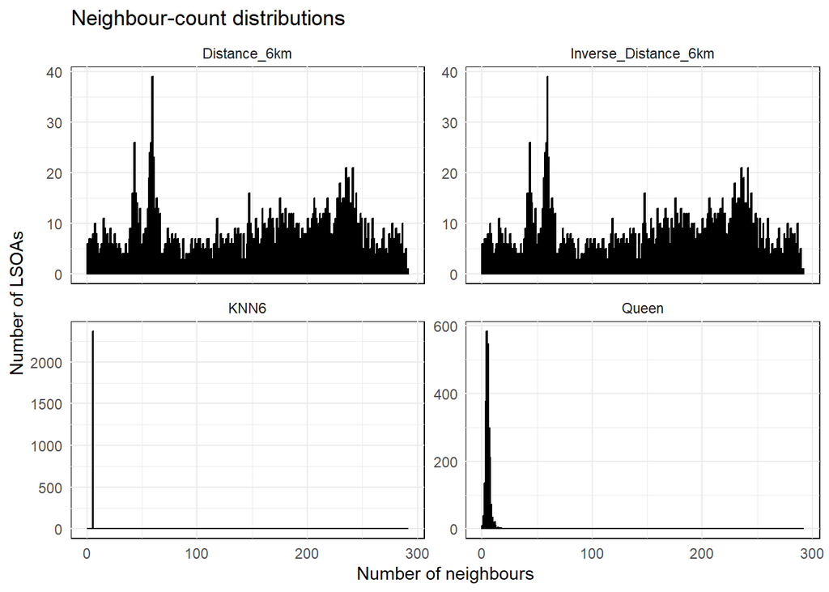

```r
neighbour_data <- map2_dfr(
  nb_objects,
  names(nb_objects),
  function(nb, method) {

    tibble(
      Method = method,
      Neighbours = card(nb)
    )
  }
)

ggplot(
  neighbour_data,
  aes(x = Neighbours)
) +
  geom_histogram(
    binwidth = 1,
    boundary = 0,
    colour = "black",
    fill = "steelblue"
  ) +
  facet_wrap(
    ~ Method,
    scales = "free_y"
  ) +
  labs(
    title = "Neighbour-count distributions",
    x = "Number of neighbours",
    y = "Number of LSOAs"
  ) +
  theme_minimal() +
  theme(
    plot.background = element_rect(fill = "white"),
    panel.background = element_rect(fill = "white")
  )
```

# 13 13. Map the neighbour counts

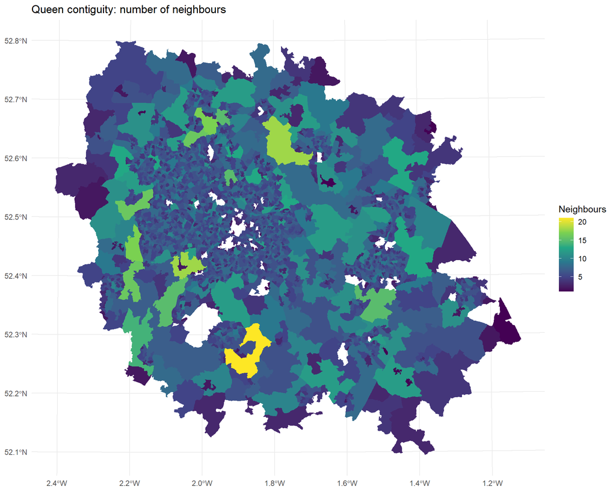

```r
# Attach neighbour counts to the analytical data
food_analysis$Queen <- card(nb_queen)
food_analysis$KNN6 <- card(nb_knn6)
food_analysis$Distance_6km <- card(nb_dist6)

# Queen map
ggplot(food_analysis) +
  geom_sf(aes(fill = Queen), colour = NA) +
  scale_fill_viridis_c() +
  labs(
    title = "Queen contiguity: number of neighbours",
    fill = "Neighbours"
  ) +
  theme_minimal()
```

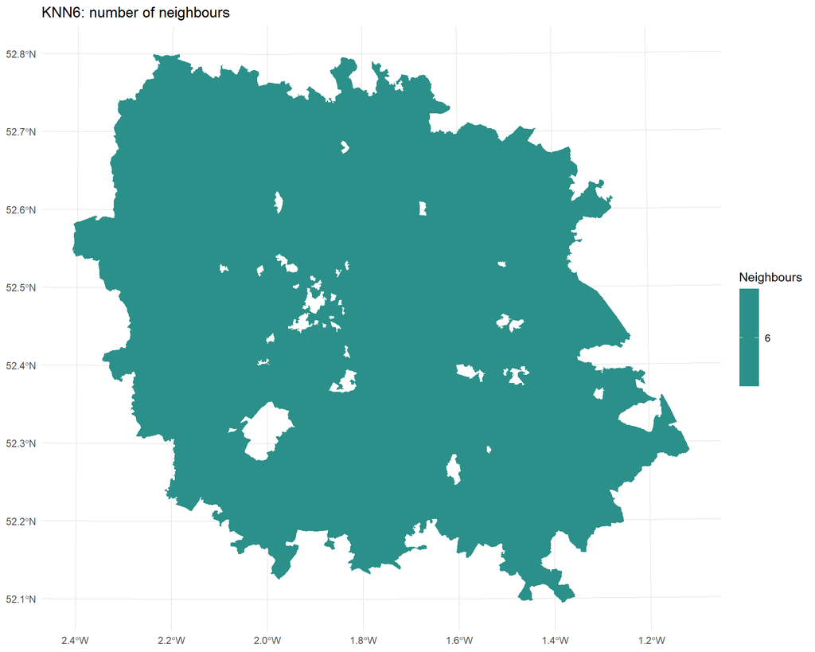

```r
# KNN6 map
ggplot(food_analysis) +
  geom_sf(aes(fill = KNN6), colour = NA) +
  scale_fill_viridis_c() +
  labs(
    title = "KNN6: number of neighbours",
    fill = "Neighbours"
  ) +
  theme_minimal()
```

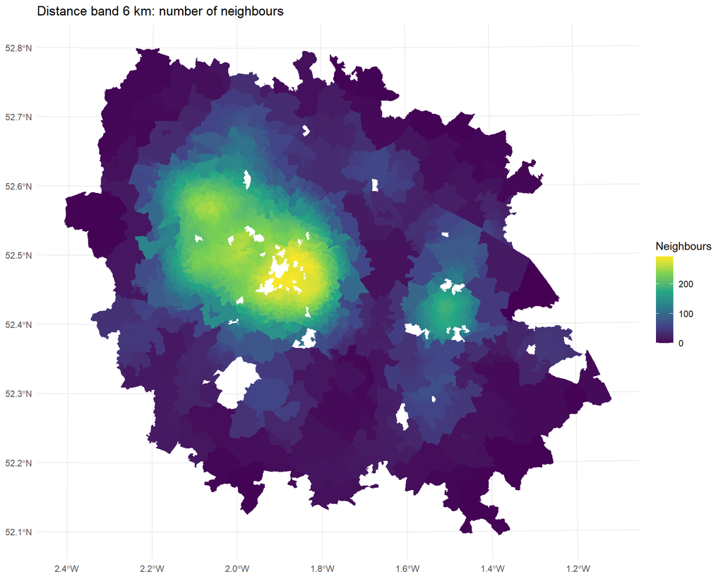

```r
# Distance-band map
ggplot(food_analysis) +
  geom_sf(aes(fill = Distance_6km), colour = NA) +
  scale_fill_viridis_c() +
  labs(
    title = "Distance band 6 km: number of neighbours",
    fill = "Neighbours"
  ) +
  theme_minimal()
```

# 14 14. Compare the four spatial weights objects

```r
# Summary of each weights object
for (method in names(lw_objects)) {

  cat("\n====================================\n")
  cat("SPATIAL WEIGHTS:", method, "\n")
  cat("====================================\n")

  print(summary(lw_objects[[method]]))
}
```

```
##
## ====================================
## SPATIAL WEIGHTS: Queen
## ====================================
## Characteristics of weights list object:
## Neighbour list object:
## Number of regions: 2365
## Number of nonzero links: 13724
## Percentage nonzero weights: 0.2453683
## Average number of links: 5.80296
## Link number distribution:
##
##   1   2   3   4   5   6   7   8   9  10  11  12  13  14  15  16  17  18  21
##   9  39 136 378 583 546 298 210  71  33  19  21   9   1   4   3   2   2   1
## 9 least connected regions:
## E01009146 E01010180 E01025820 E01026994 E01029618 E01031032 E01031200 E01031201 E01031302 with 1 link
## 1 most connected region:
## E01031213 with 21 links
##
## Weights style: W
## Weights constants summary:
##      n      nn   S0       S1       S2
## W 2365 5593225 2365 865.7787 9832.017
##
## ====================================
## SPATIAL WEIGHTS: KNN6
## ====================================
## Characteristics of weights list object:
## Neighbour list object:
## Number of regions: 2365
## Number of nonzero links: 14190
## Percentage nonzero weights: 0.2536998
## Average number of links: 6
## Non-symmetric neighbours list
## Link number distribution:
##
##    6
## 2365
## 2365 least connected regions:
## E01009143 E01009145 E01009146 E01009147 E01009151 E01009152 E01009153 E01009155 E01009157 E01009158 E01009159 E01009160 E01009161 E01009162 E01009163 E01009164 E01009165 E01009166 E01009167 E01009168 E01009169 E01009170 E01009171 E01009172 E01009173 E01009174 E01009175 E01009176 E01009177 E010091…
```

[output cut: 98 more lines]

```
## 240 241 242 243 244 245 246 247 248 249 250 251 252 253 254 255 256 257 258 259
##  14  14  21  13  13  16  10  10   7  12  11   5   5  11   7   7  10   4   5   7
## 260 261 262 263 264 265 266 267 268 269 270 271 272 273 274 275 276 277 278 279
##  11   7   2   4   6   4   5   5   4   7   9   2   5   4   3   8   7   5  10   7
## 280 281 282 283 284 285 286 287 288 289 290 291 292
##   6   9   8   4   8   4   6  10   4   4   5   1   1
## 5 least connected regions:
## E01025913 E01026999 E01028859 E01031194 E01031197 with 1 link
## 1 most connected region:
## E01008996 with 292 links
##
## Weights style: W
## Weights constants summary:
##      n      nn   S0       S1      S2
## W 2364 5588496 2364 105.9247 9527.56
```

# 15 15. Global Moran’s I — analytical inference

Global Moran’s I measures the overall spatial autocorrelation of EFDI.

The four methods use the same EFDI variable and observations, but different spatial weights.

```r
# EFDI values
y <- food_analysis$efdi

# Analytical Global Moran's I tests
global_tests <- lapply(
  lw_objects,
  function(lw) {

    moran.test(
      y,
      lw,
      randomisation = TRUE,
      zero.policy = TRUE
    )
  }
)

# Extract results
global_summary <- map2_dfr(
  global_tests,
  names(global_tests),
  function(test, method) {

    tibble(
      Method = method,
      Moran_I = as.numeric(test$estimate[1]),
      Expected_I = as.numeric(test$estimate[2]),
      Variance = as.numeric(test$estimate[3]),
      Statistic = as.numeric(test$statistic),
      P_value = test$p.value
    )
  }
)

knitr::kable(
  global_summary,
  digits = 6,
  caption = "Global Moran's I — analytical inference"
)
```

Global Moran’s I — analytical inference

| Method | Moran_I | Expected_I | Variance | Statistic | P_value |
| --- | --- | --- | --- | --- | --- |
| Queen | 0.453153 | -0.000423 | 0.000154 | 36.50006 | 0 |
| KNN6 | 0.431819 | -0.000423 | 0.000126 | 38.47010 | 0 |
| Distance_6km | 0.148439 | -0.000423 | 0.000013 | 40.77702 | 0 |
| Inverse_Distance_6km | 0.214247 | -0.000423 | 0.000019 | 49.78509 | 0 |

# 16 16. Global Moran’s I — permutation inference

The permutation test compares the observed Global Moran’s I with values generated by randomly reallocating EFDI values across the fixed spatial weights.

```r
set.seed(12345)

global_permutation <- lapply(
  lw_objects,
  function(lw) {

    moran.mc(
      y,
      lw,
      nsim = 999,
      zero.policy = TRUE
    )
  }
)

permutation_summary <- map2_dfr(
  global_permutation,
  names(global_permutation),
  function(test, method) {

    tibble(
      Method = method,
      Moran_I = as.numeric(test$statistic),
      P_value = test$p.value,
      Permutations = 999
    )
  }
)

knitr::kable(
  permutation_summary,
  digits = 6,
  caption = "Global Moran's I — permutation inference"
)
```

Global Moran’s I — permutation inference

| Method | Moran_I | P_value | Permutations |
| --- | --- | --- | --- |
| Queen | 0.453153 | 0.001 | 999 |
| KNN6 | 0.431819 | 0.001 | 999 |
| Distance_6km | 0.148439 | 0.001 | 999 |
| Inverse_Distance_6km | 0.214247 | 0.001 | 999 |

# 17 17. Map EFDI distribution

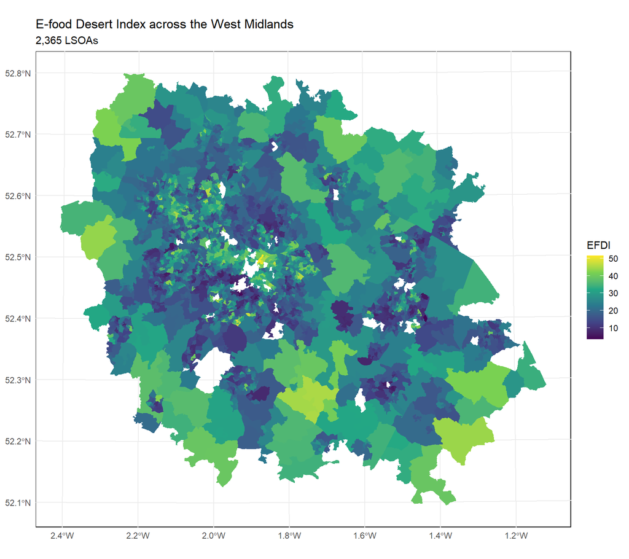

```r
ggplot(food_analysis) +
  geom_sf(
    aes(fill = efdi),
    colour = NA
  ) +
  scale_fill_viridis_c(
    option = "viridis",
    name = "EFDI"
  ) +
  labs(
    title = "E-food Desert Index across the West Midlands",
    subtitle = "2,365 LSOAs"
  ) +
  theme_minimal() +
  theme(
    plot.background = element_rect(fill = "white"),
    panel.background = element_rect(fill = "white")
  )
```

# 18 18. Local Moran’s I — LISA analysis

Local Moran’s I identifies local spatial clusters and spatial outliers.

The analysis calculates:

- Local Moran’s I
- Expected local Moran’s I
- Local variance
- Z-score
- Analytical p-value
- Spatial lag
- Quadrant classification

```r
calculate_lisa <- function(data, y, lw) {

  # Local Moran's I
  lisa <- localmoran(
    y,
    lw,
    zero.policy = TRUE
  )

  # Standardised EFDI
  z <- as.numeric(scale(y))

  # Spatial lag of standardised EFDI
  lag_z <- lag.listw(
    lw,
    z,
    zero.policy = TRUE
  )

  # Quadrant classification
  quadrant <- case_when(
    z >= 0 & lag_z >= 0 ~ "High-High",
    z < 0 & lag_z < 0 ~ "Low-Low",
    z < 0 & lag_z >= 0 ~ "Low-High",
    z >= 0 & lag_z < 0 ~ "High-Low"
  )

  # Store local Moran results
  output <- data %>%
    mutate(
      local_I = lisa[, "Ii"],
      expected_local_I = lisa[, "E.Ii"],
      local_variance = lisa[, "Var.Ii"],
      local_Z = lisa[, "Z.Ii"],
      local_p = lisa[, "Pr(z != E(Ii))"],
      spatial_lag = lag_z,
      quadrant = quadrant,
      cluster = ifelse(
        local_p < 0.05,
        quadrant,
        "Not significant"
      )
    )

  output
}
```

# 19 19. Run Local Moran’s I for all four methods

```r
lisa_results <- lapply(
  lw_objects,
  function(lw) {

    calculate_lisa(
      food_analysis,
      y,
      lw
    )
  }
)

names(lisa_results) <- names(lw_objects)

# Inspect Queen results
head(
  lisa_results$Queen %>%
    st_drop_geometry() %>%
    select(
      lsoa01cd,
      efdi,
      local_I,
      expected_local_I,
      local_variance,
      local_Z,
      local_p,
      quadrant,
      cluster
    )
)
```

```
##    lsoa01cd     efdi     local_I expected_local_I local_variance    local_Z
## 1 E01009143 38.30457 -0.04571522    -1.595047e-03     0.53667242 -0.0602258
## 2 E01009145 18.79994  0.05672165    -5.048122e-05     0.01189274  0.5205882
## 3 E01009146 26.37110 -0.77245248    -1.244520e-04     0.29429232 -1.4236798
## 4 E01009147 18.25160  0.41895337    -7.102361e-05     0.02793392  2.5071099
## 5 E01009151 26.51394  0.31046210    -1.322574e-04     0.06244357  1.2429386
## 6 E01009152 29.58538  0.44527493    -3.575238e-04     0.14057552  1.1885624
##      local_p  quadrant         cluster
## 1 0.95197580  High-Low Not significant
## 2 0.60265369   Low-Low Not significant
## 3 0.15453918  High-Low Not significant
## 4 0.01217229   Low-Low         Low-Low
## 5 0.21389045 High-High Not significant
## 6 0.23461193 High-High Not significant
```

# 20 20. Compare Local Moran’s I cluster counts

```r
lisa_counts <- map2_dfr(
  lisa_results,
  names(lisa_results),
  function(data, method) {

    data %>%
      st_drop_geometry() %>%
      count(cluster) %>%
      mutate(Method = method)
  }
) %>%
  select(
    Method,
    cluster,
    n
  )

knitr::kable(
  lisa_counts,
  caption = "LISA cluster counts by spatial weights"
)
```

LISA cluster counts by spatial weights

| Method | cluster | n |
| --- | --- | --- |
| Queen | High-High | 263 |
| Queen | High-Low | 14 |
| Queen | Low-High | 25 |
| Queen | Low-Low | 218 |
| Queen | Not significant | 1845 |
| KNN6 | High-High | 278 |
| KNN6 | High-Low | 24 |
| KNN6 | Low-High | 32 |
| KNN6 | Low-Low | 289 |
| KNN6 | Not significant | 1742 |
| Distance_6km | High-High | 524 |
| Distance_6km | High-Low | 194 |
| Distance_6km | Low-High | 321 |
| Distance_6km | Low-Low | 616 |
| Distance_6km | Not significant | 709 |
| Distance_6km | NA | 1 |
| Inverse_Distance_6km | High-High | 515 |
| Inverse_Distance_6km | High-Low | 167 |
| Inverse_Distance_6km | Low-High | 203 |
| Inverse_Distance_6km | Low-Low | 646 |
| Inverse_Distance_6km | Not significant | 833 |
| Inverse_Distance_6km | NA | 1 |

# 21 21. Create LISA cluster maps

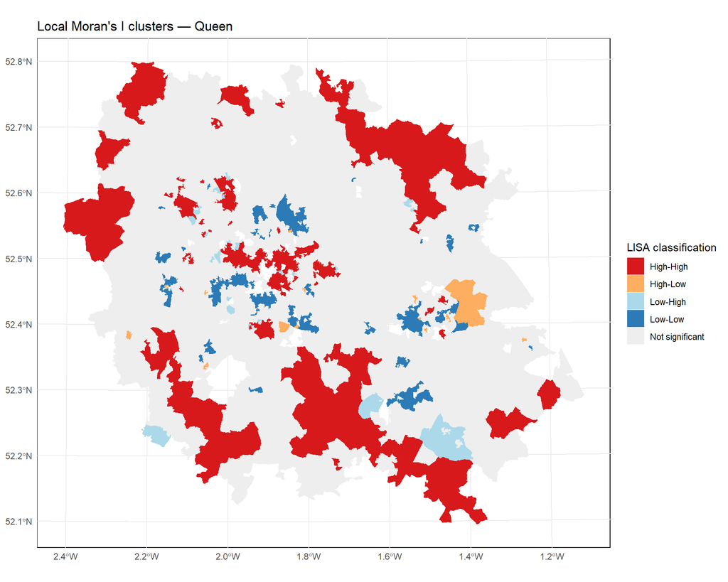

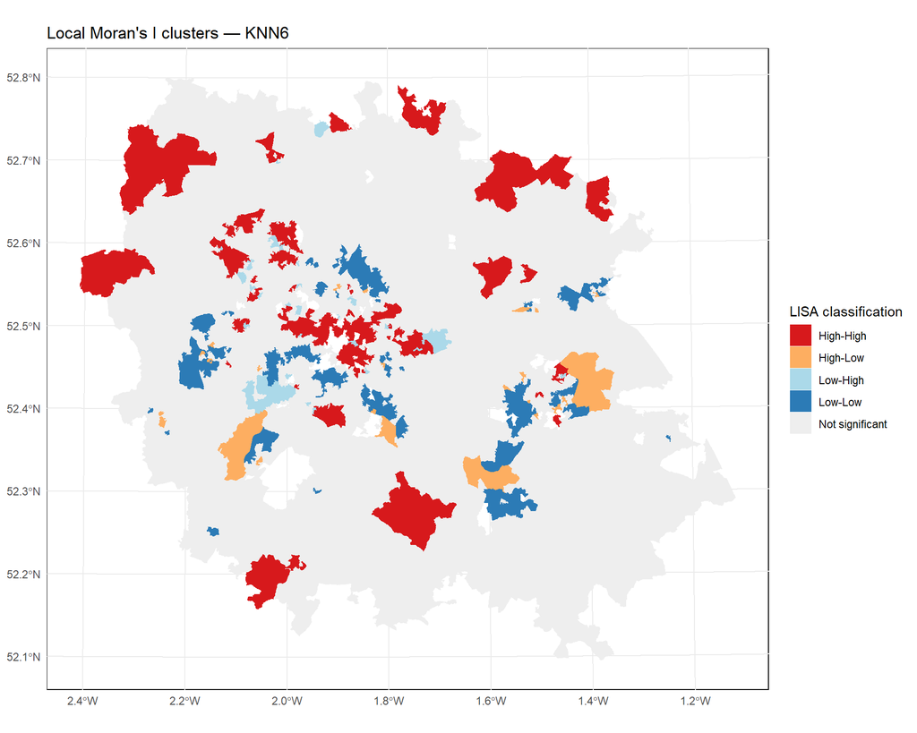

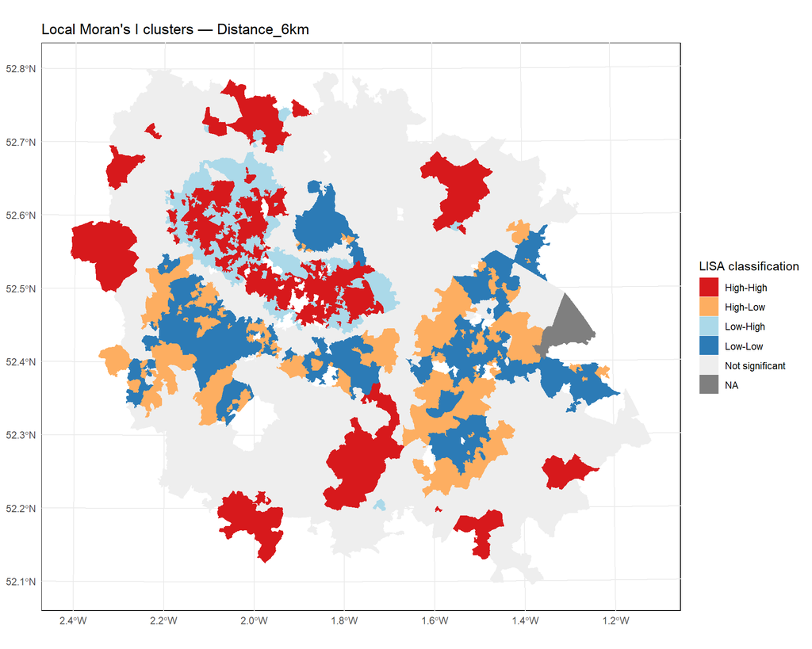

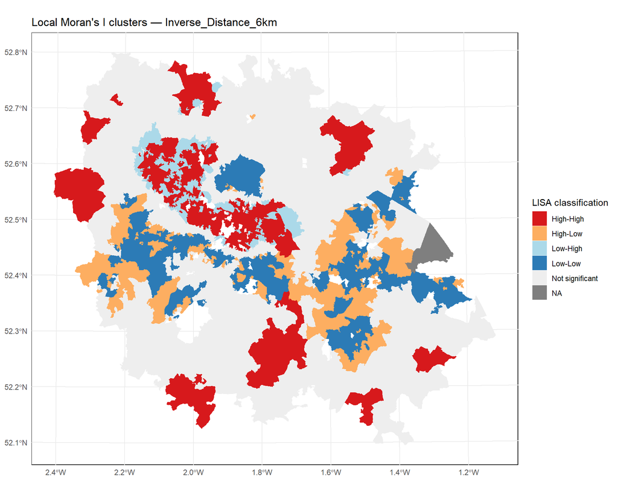

```r
cluster_colours <- c(
  "High-High" = "#d7191c",
  "Low-Low" = "#2c7bb6",
  "Low-High" = "#abd9e9",
  "High-Low" = "#fdae61",
  "Not significant" = "#eeeeee"
)

for (method in names(lisa_results)) {

  p <- ggplot(lisa_results[[method]]) +
    geom_sf(
      aes(fill = cluster),
      colour = NA
    ) +
    scale_fill_manual(
      values = cluster_colours,
      drop = FALSE
    ) +
    labs(
      title = paste(
        "Local Moran's I clusters —",
        method
      ),
      fill = "LISA classification"
    ) +
    theme_minimal() +
    theme(
      plot.background = element_rect(fill = "white"),
      panel.background = element_rect(fill = "white")
    )

  print(p)
}
```

# 22 22. Map Local Moran’s I values

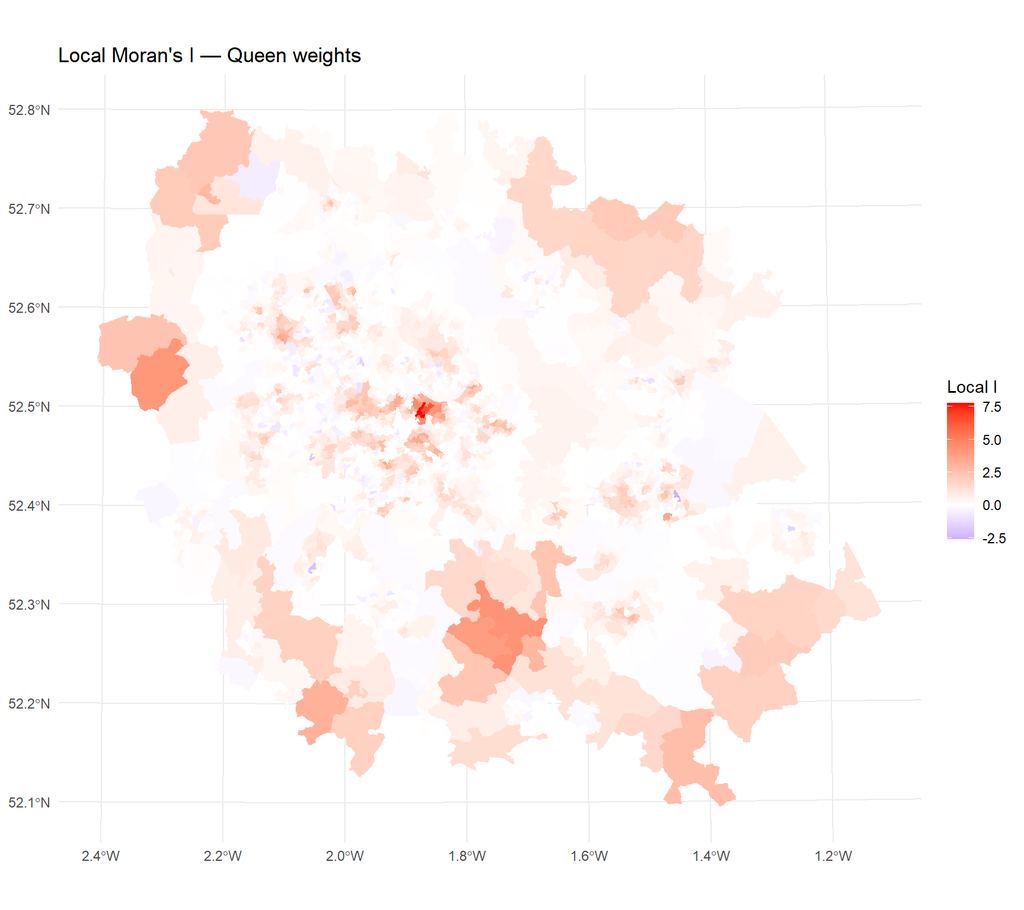

```r
ggplot(lisa_results$Queen) +
  geom_sf(
    aes(fill = local_I),
    colour = NA
  ) +
  scale_fill_gradient2(
    low = "blue",
    mid = "white",
    high = "red"
  ) +
  labs(
    title = "Local Moran's I — Queen weights",
    fill = "Local I"
  ) +
  theme_minimal()
```

# 23 23. Map local variance

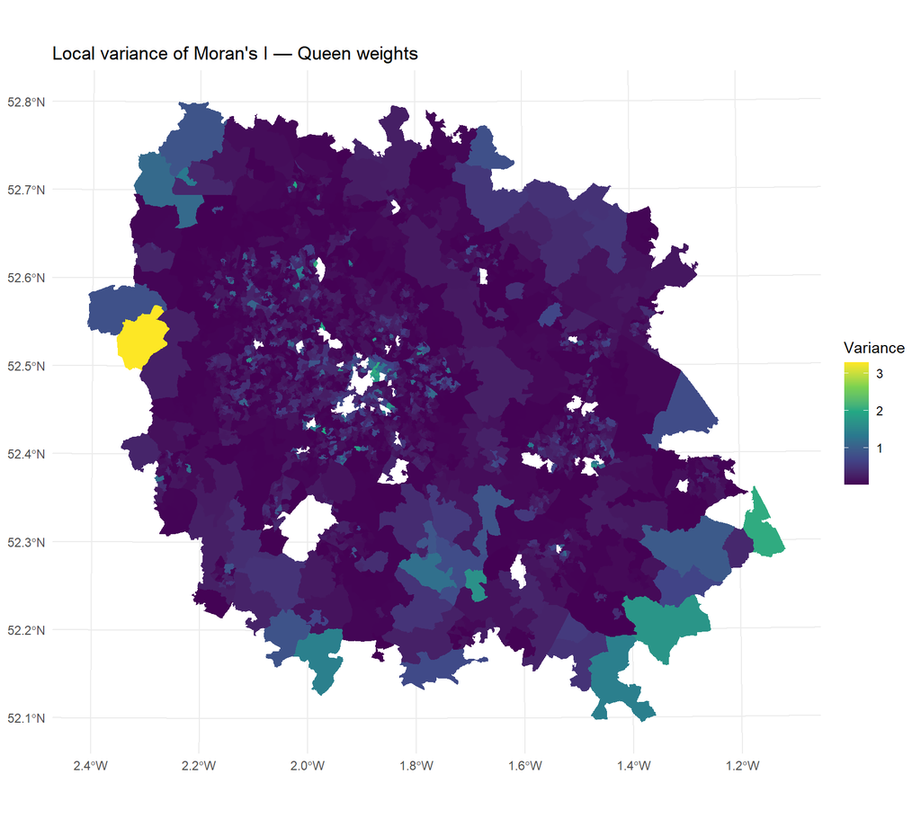

```r
ggplot(lisa_results$Queen) +
  geom_sf(
    aes(fill = local_variance),
    colour = NA
  ) +
  scale_fill_viridis_c() +
  labs(
    title = "Local variance of Moran's I — Queen weights",
    fill = "Variance"
  ) +
  theme_minimal()
```

# 24 24. Export analytical results

```r
# Export LISA results for all four methods
for (method in names(lisa_results)) {

  output_path <- file.path(
    project_dir,
    paste0(
      "efdi_lisa_",
      tolower(method),
      ".gpkg"
    )
  )

  st_write(
    lisa_results[[method]],
    output_path,
    delete_dsn = TRUE,
    quiet = TRUE
  )
}

# Export Global Moran analytical results
write.csv(
  global_summary,
  file.path(
    project_dir,
    "global_moran_analytical.csv"
  ),
  row.names = FALSE
)

# Export Global Moran permutation results
write.csv(
  permutation_summary,
  file.path(
    project_dir,
    "global_moran_permutation.csv"
  ),
  row.names = FALSE
)

# Export LISA cluster counts
write.csv(
  lisa_counts,
  file.path(
    project_dir,
    "lisa_cluster_comparison.csv"
  ),
  row.names = FALSE
)
```

# 25 25. Final comparison and interpretation

The four weighting methods represent different assumptions about spatial relationships.

| Method | Neighbour definition | Main characteristic |
| --- | --- | --- |
| Queen | Shared edge or corner | Physical polygon contiguity |
| KNN6 | Six nearest representative points | Fixed number of neighbours |
| Distance band | Representative points within 6 km | Variable number of neighbours |
| Inverse distance | Within 6 km, weighted by inverse distance | Closer locations receive greater weights |

Compare the following:

1. How the number of neighbours differs between methods.
2. Whether Global Moran’s I changes between weighting methods.
3. Whether permutation tests support the same conclusion.
4. Whether High–High and Low–Low clusters occur in similar locations.
5. Whether local spatial outliers change.
6. Which weighting method best represents the spatial interaction process relevant to EFDI.

The final methodological choice should be justified by the nature of the EFDI application, not simply by selecting the method with the largest Moran’s I.

# 26 26. Important methodological notes

- The analytical dataset contains 2,365 LSOAs with EFDI values.
- The coordinate reference system is EPSG:27700.
- The active geometry column is `geom`.
- The four methods use the same observations and EFDI variable.
- KNN6 and distance-band neighbours are based on representative points.
- Inverse-distance weights use the same 6 km neighbourhood definition and power 1.
- All four weights objects are row-standardised using style `"W"`.
- Global Moran’s I analytical and permutation tests are reported separately.
- Local Moran’s I in this document uses analytical p-values from `localmoran()`. These are not the same as Python’s permutation-based local p-values.
- Local p-values use an unadjusted 0.05 threshold. Consider multiple-testing correction before making strong claims about individual LSOAs.
- Results should be interpreted only after successfully running the code and checking the outputs.